# 10-8-19 exploratory analysis

Megan Beaudry

10/8/2019

# Exploratory Analysis

##Prelimnary Loading Load clean data

```r
clean_water_quality_data <- readRDS("~/Desktop/epid8060fall2019/MeganBeaudry-Project_WQ/data/processed_data/clean_water_quality_data.rds")
```

Load libraries

```r
library(ggplot2)
library(ggthemes)
library(RColorBrewer)
library(dplyr)
```

##Exploratory Analysis - Summary Statistics

```r
summary(clean_water_quality_data$Rainfall)
```

```
##    Length     Class      Mode
##       533 character character
```

```r
summary(clean_water_quality_data$HF183)
```

```
##    Min. 1st Qu.  Median    Mean 3rd Qu.    Max.
##   3.263   3.330   3.330   3.492   3.632   6.038
```

```r
summary(clean_water_quality_data$HumM2)
```

```
##    Min. 1st Qu.  Median    Mean 3rd Qu.    Max.
##   3.336   3.847   3.847   3.870   3.847   5.057
```

```r
summary(clean_water_quality_data$CG01)
```

```
##    Min. 1st Qu.  Median    Mean 3rd Qu.    Max.
##   3.109   3.109   3.109   3.125   3.109   4.871
```

```r
summary(clean_water_quality_data$LeeSg)
```

```
##    Min. 1st Qu.  Median    Mean 3rd Qu.    Max.
##   3.284   3.284   3.284   3.330   3.284   4.709
```

```r
summary(clean_water_quality_data$Dog3)
```

```
##    Min. 1st Qu.  Median    Mean 3rd Qu.    Max.
##   3.157   3.157   3.157   3.169   3.157   4.547
```

```r
summary(clean_water_quality_data$MuBac)
```

```
##    Min. 1st Qu.  Median    Mean 3rd Qu.    Max.
##   3.378   3.555   3.555   3.559   3.555   4.366
```

```r
summary(clean_water_quality_data$Rum2Bac)
```

```
##    Min. 1st Qu.  Median    Mean 3rd Qu.    Max.
##   3.255   3.457   3.457   3.464   3.457   5.231
```

```r
summary(clean_water_quality_data$A_butlzeri_HSP60)
```

```
## Length  Class   Mode
##      0   NULL   NULL
```

```r
summary(clean_water_quality_data$Salmonella_spp_InvA)
```

```
##    Min. 1st Qu.  Median    Mean 3rd Qu.    Max.
##   3.171   3.171   3.171   3.173   3.171   3.472
```

```r
summary(clean_water_quality_data$Campylobacter_spp_Van_Dkye)
```

```
##    Min. 1st Qu.  Median    Mean 3rd Qu.    Max.
##   3.487   3.555   3.555   3.571   3.555   4.369
```

```r
summary(clean_water_quality_data$Enterococcus_CCE)
```

```
##    Min. 1st Qu.  Median    Mean 3rd Qu.    Max.    NA's
##  0.6021  2.0774  2.4297  2.6199  2.8797 52.1365       2
```

```r
summary(clean_water_quality_data$total_coliforms)
```

```
##    Min. 1st Qu.  Median    Mean 3rd Qu.    Max.    NA's
##   1.255   2.862   3.384   3.067   3.384   3.384      61
```

```r
summary(clean_water_quality_data$E_coli)
```

```
##    Min. 1st Qu.  Median    Mean 3rd Qu.    Max.    NA's
##  0.0000  0.6021  1.2788  1.3119  1.8736  3.3837       3
```

```r
summary(clean_water_quality_data$Enteroalert)
```

```
##    Length     Class      Mode
##       533 character character
```

```r
summary(clean_water_quality_data$thermotolerant_coliforms)
```

```
##    Min. 1st Qu.  Median    Mean 3rd Qu.    Max.    NA's
##  0.0000  0.9542  1.3010  1.5138  2.0000  2.9375       1
```

##Exploratory Analysis - Temporal Trends

*Temporal Trends All Pond Comparison* Comparison with traditional water quality indicators and Arco. I am really unhappy with this figure. I need to brainstorm a better way to represent data

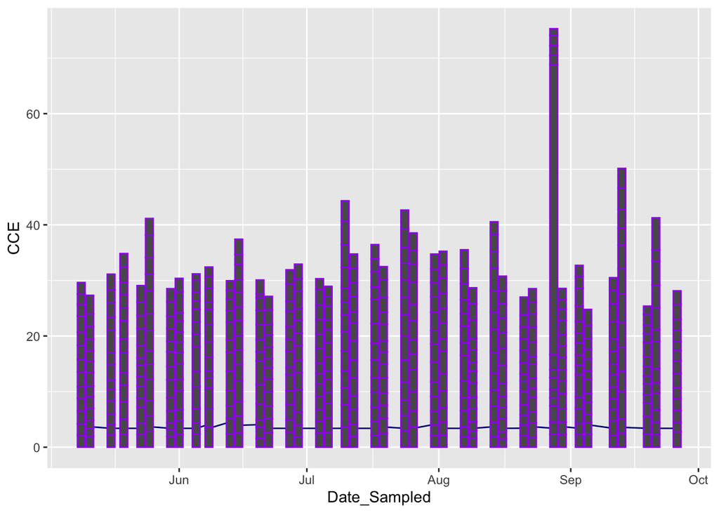

```r
ggplot(clean_water_quality_data) +
  geom_line(mapping = aes(x = Date_Sampled, y = A_butzleri_HSP60), color = "navy") +
  geom_bar(mapping = aes(x = Date_Sampled, y = Enterococcus_CCE), color = "purple", stat = "identity") +
  ylab("CCE")
```

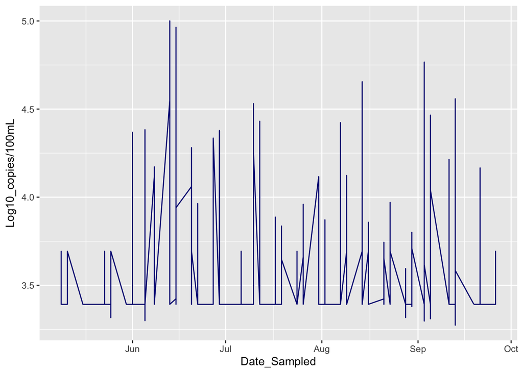

```r
ggplot(clean_water_quality_data) +
  geom_line(mapping = aes(x = Date_Sampled, y = A_butzleri_HSP60), color = "navy") +
  ylab(expression("Log10_copies/100mL"))
```

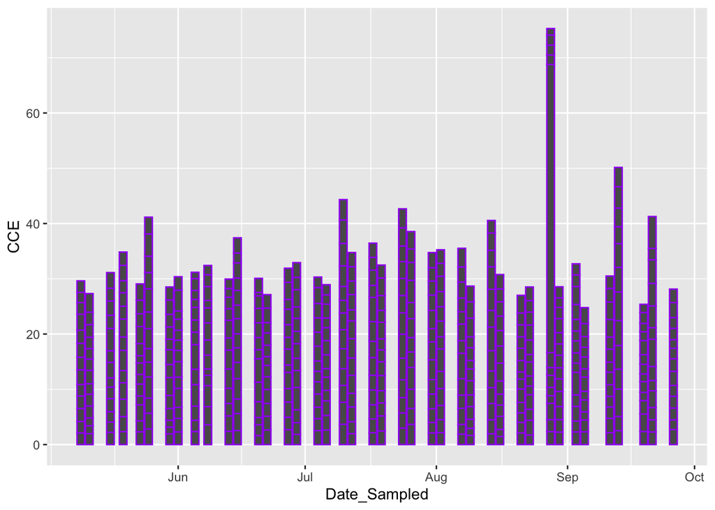

```r
ggplot(clean_water_quality_data) +
  geom_bar(mapping = aes(x = Date_Sampled, y = Enterococcus_CCE), color = "purple", stat = "identity") +
  ylab("CCE")
```

The temporal trends by pond of HF183, HumM2 & A. butzleri to see if there was a relationship between source and pathogen

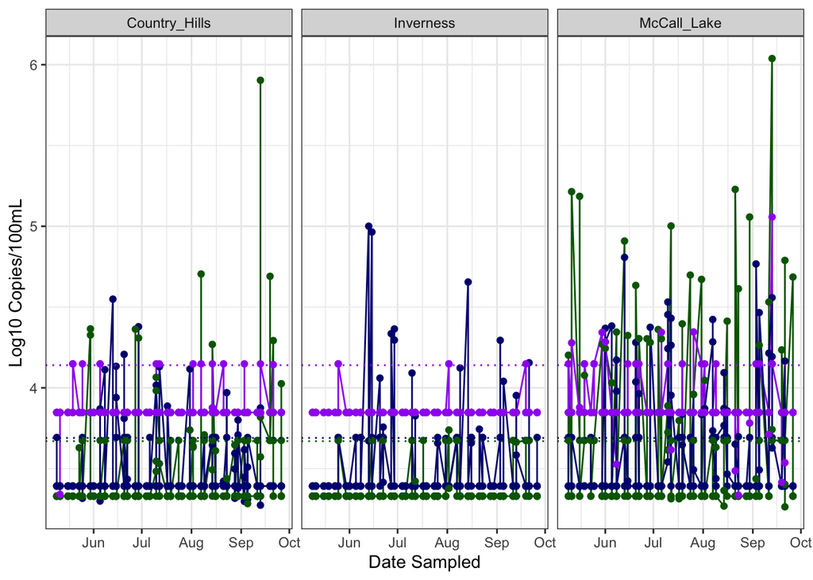

```r
All_Human_Arco <- ggplot(clean_water_quality_data) +
  geom_line(mapping = aes(x = Date_Sampled, y = HF183), color = "dark green") +
  geom_line(mapping = aes(x = Date_Sampled, y = HumM2), color = "purple") +
  geom_line(mapping = aes(x = Date_Sampled, y = A_butzleri_HSP60), color = "navy") +
  geom_point(mapping = aes(x = Date_Sampled, y = A_butzleri_HSP60), color = "navy") +
  geom_point(mapping = aes(x = Date_Sampled, y = HF183), color = "dark green") +
  geom_point(mapping = aes(x = Date_Sampled, y = HumM2), color = "purple") +
  labs (x = "Date Sampled", y = "Log10 Copies/100mL") +
  facet_wrap(~ Pond) +
  geom_hline(yintercept = 3.67, colour = "dark green", linetype = "dotted") +
  geom_hline(yintercept = 4.14, colour = "purple", linetype = "dotted") +
  geom_hline(yintercept = 3.69, colour = "navy", linetype = "dotted") +
  theme_bw()
All_Human_Arco
```

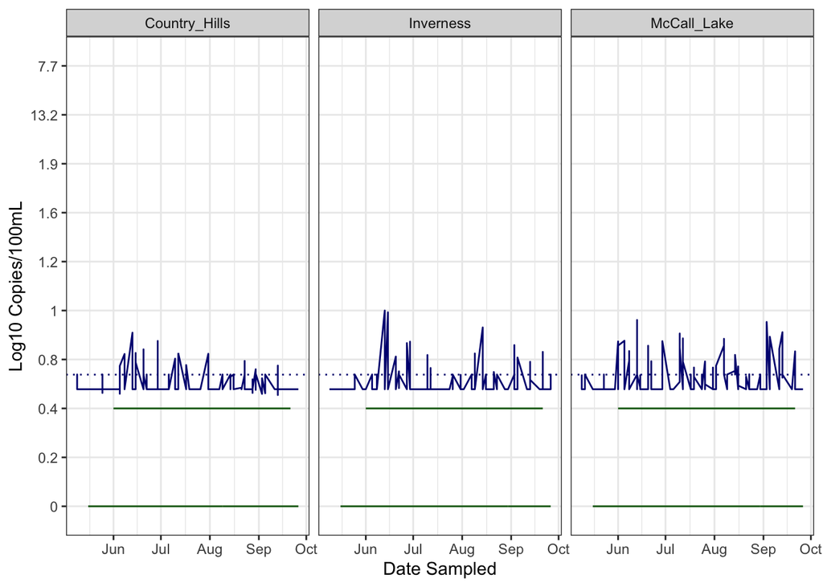

```r
ggsave(filename = "../../results/All_Human_Arco.png",plot = All_Human_Arco)
All_rain_Arco <- ggplot(clean_water_quality_data) +
  geom_line(mapping = aes(x = Date_Sampled, y = Rainfall), color = "dark green") +
  geom_line(mapping = aes(x = Date_Sampled, y = A_butzleri_HSP60), color = "navy") +
  labs (x = "Date Sampled", y = "Log10 Copies/100mL") +
  facet_wrap(~ Pond) +
  geom_hline(yintercept = 3.69, colour = "navy", linetype = "dotted") +
  theme_bw()
All_rain_Arco
```

```r
ggsave(filename = "../../results/All_rain_Arco.png",plot = All_rain_Arco)
```

*Temporal Trends grouped by Pond and Source* Temporal trend of each pond individually with pathogen and source

Part 1: Human and Arco

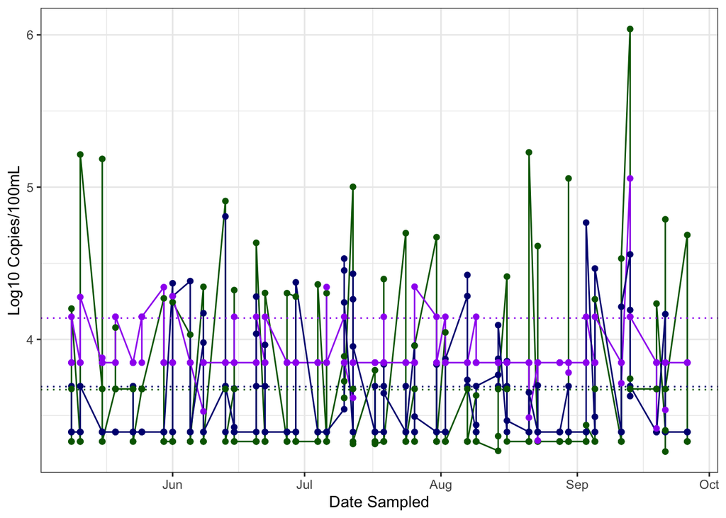

```r
McCall_Human_Arco <- clean_water_quality_data %>%
  filter(Pond == "McCall_Lake") %>%
  ggplot() +
  geom_line(mapping = aes(x = Date_Sampled, y = HF183), color = "dark green") +
  geom_line(mapping = aes(x = Date_Sampled, y = HumM2), color = "purple") +
  geom_line(mapping = aes(x = Date_Sampled, y = A_butzleri_HSP60), color = "navy") +
  geom_hline(yintercept = 3.67, colour = "dark green", linetype = "dotted") +
  geom_hline(yintercept = 4.14, colour = "purple", linetype = "dotted") +
  geom_hline(yintercept = 3.69, colour = "navy", linetype = "dotted") +
  geom_point(mapping = aes(x = Date_Sampled, y = A_butzleri_HSP60), color = "navy") +
  geom_point(mapping = aes(x = Date_Sampled, y = HF183), color = "dark green") +
  geom_point(mapping = aes(x = Date_Sampled, y = HumM2), color = "purple") +
  labs (x = "Date Sampled", y = "Log10 Copies/100mL") +
  theme_bw()
McCall_Human_Arco
```

```r
ggsave(filename = "../../results/McCall_Human_Arco.png",plot = McCall_Human_Arco)
```

All pathogens in McCall

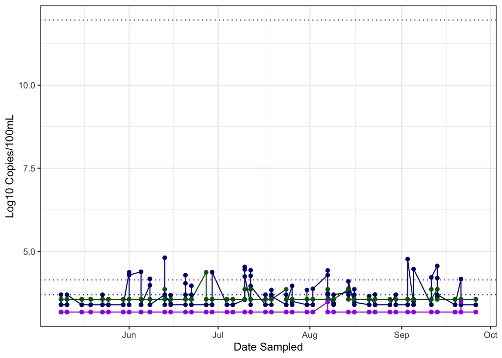

```r
McCall_Pathogens <- clean_water_quality_data %>%
  filter(Pond == "McCall_Lake") %>%
  ggplot() +
  geom_line(mapping = aes(x = Date_Sampled, y = Campylobacter_spp_Van_Dkye), color = "dark green") +
  geom_line(mapping = aes(x = Date_Sampled, y = Salmonella_spp_InvA), color = "purple") +
  geom_line(mapping = aes(x = Date_Sampled, y = A_butzleri_HSP60), color = "navy") +
  geom_hline(yintercept = 11.96, colour = "dark green", linetype = "dotted") +
  geom_hline(yintercept = 4.14, colour = "purple", linetype = "dotted") +
  geom_hline(yintercept = 3.69, colour = "navy", linetype = "dotted") +
  geom_point(mapping = aes(x = Date_Sampled, y = A_butzleri_HSP60), color = "navy") +
  geom_point(mapping = aes(x = Date_Sampled, y = Campylobacter_spp_Van_Dkye), color = "dark green") +
  geom_point(mapping = aes(x = Date_Sampled, y = Salmonella_spp_InvA), color = "purple") +
  labs (x = "Date Sampled", y = "Log10 Copies/100mL") +
  theme_bw()
McCall_Pathogens
```

```r
ggsave(filename = "../../results/McCall_Pathogens.png",plot = McCall_Pathogens)
```

Took out Salmonella because we didnt find any…However THIS graph looks horrible becasue the LOD for campy is so high compared to the others (i.e., 11 to 3.5 on average). I need to come up with a better to show this if i want to show it. It really is a negative result, as we did not find much Campylobacter spp. However, they are highly related bacteria so some kind of relationship would be nice to show…

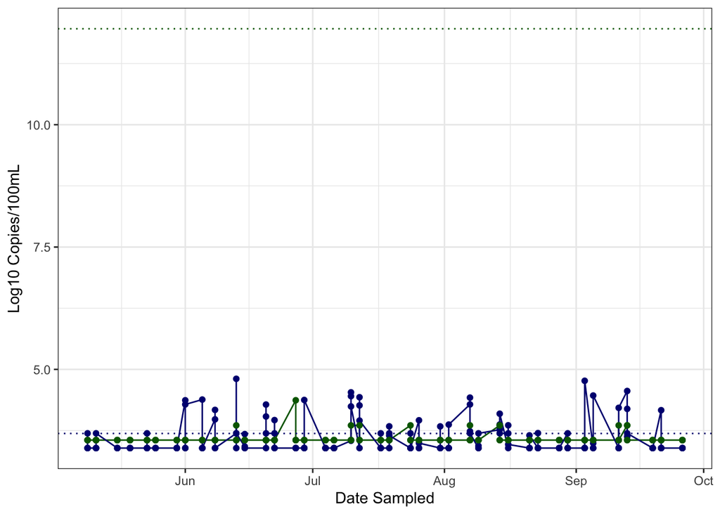

```r
McCall_Camp_Arco <- clean_water_quality_data %>%
  filter(Pond == "McCall_Lake") %>%
  ggplot() +
  geom_line(mapping = aes(x = Date_Sampled, y = Campylobacter_spp_Van_Dkye), color = "dark green") +
  geom_line(mapping = aes(x = Date_Sampled, y = A_butzleri_HSP60), color = "navy") +
  geom_hline(yintercept = 11.96, colour = "dark green", linetype = "dotted") +
  geom_hline(yintercept = 3.69, colour = "navy", linetype = "dotted") +
  geom_point(mapping = aes(x = Date_Sampled, y = A_butzleri_HSP60), color = "navy") +
  geom_point(mapping = aes(x = Date_Sampled, y = Campylobacter_spp_Van_Dkye), color = "dark green") +
  labs (x = "Date Sampled", y = "Log10 Copies/100mL") +
  theme_bw()
McCall_Camp_Arco
```

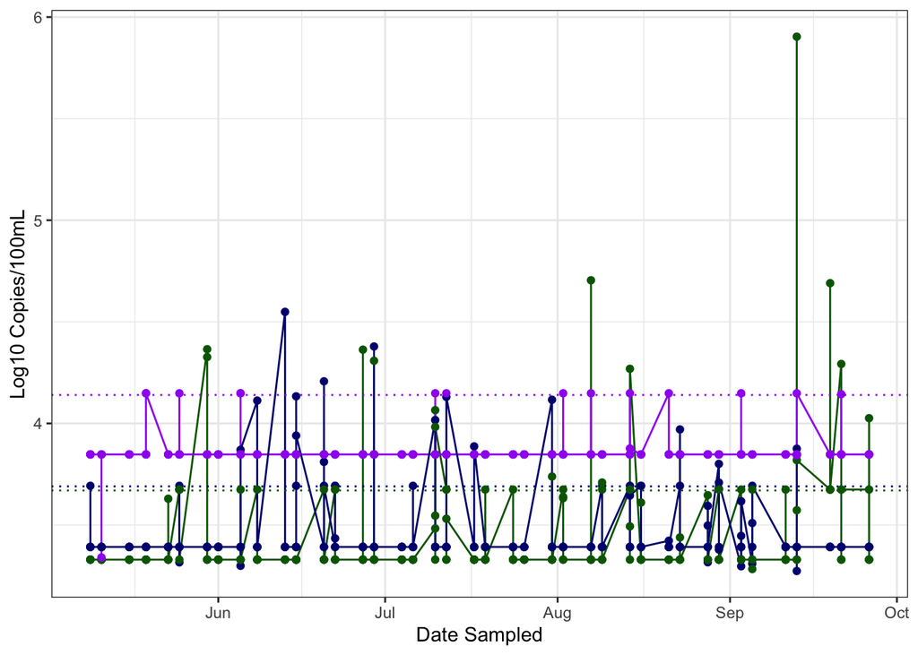

```r
ggsave(filename = "../../results/McCall_Camp_arco.png",plot = McCall_Camp_Arco)
Country_Hills_Hum_Arco<- clean_water_quality_data %>%
  filter(Pond == "Country_Hills") %>%
  ggplot() +
  geom_line(mapping = aes(x = Date_Sampled, y = HF183), color = "dark green") +
  geom_line(mapping = aes(x = Date_Sampled, y = HumM2), color = "purple") +
  geom_line(mapping = aes(x = Date_Sampled, y = A_butzleri_HSP60), color = "navy") +
  geom_hline(yintercept = 3.67, colour = "dark green", linetype = "dotted") +
  geom_hline(yintercept = 4.14, colour = "purple", linetype = "dotted") +
  geom_hline(yintercept = 3.69, colour = "navy", linetype = "dotted") +
  geom_point(mapping = aes(x = Date_Sampled, y = A_butzleri_HSP60), color = "navy") +
  geom_point(mapping = aes(x = Date_Sampled, y = HF183), color = "dark green") +
  geom_point(mapping = aes(x = Date_Sampled, y = HumM2), color = "purple") +
  labs (x = "Date Sampled", y = "Log10 Copies/100mL") +
  theme_bw()
Country_Hills_Hum_Arco
```

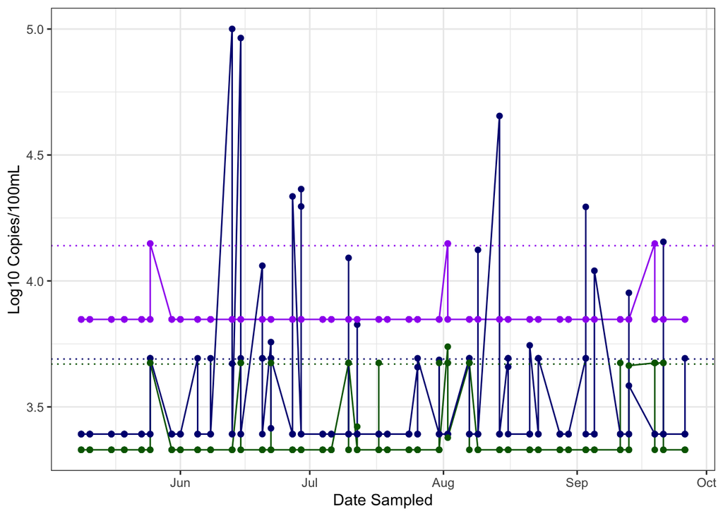

```r
ggsave(filename = "../../results/Country_Hills_Hum_Arco.png",plot = Country_Hills_Hum_Arco)
Inverness_Hum_Arco <- clean_water_quality_data %>%
  filter(Pond == "Inverness") %>%
  ggplot() +
  geom_line(mapping = aes(x = Date_Sampled, y = HF183), color = "dark green") +
  geom_line(mapping = aes(x = Date_Sampled, y = HumM2), color = "purple") +
  geom_line(mapping = aes(x = Date_Sampled, y = A_butzleri_HSP60), color = "navy") +
  geom_hline(yintercept = 3.67, colour = "dark green", linetype = "dotted") +
  geom_hline(yintercept = 4.14, colour = "purple", linetype = "dotted") +
  geom_hline(yintercept = 3.69, colour = "navy", linetype = "dotted") +
  geom_point(mapping = aes(x = Date_Sampled, y = A_butzleri_HSP60), color = "navy") +
  geom_point(mapping = aes(x = Date_Sampled, y = HF183), color = "dark green") +
  geom_point(mapping = aes(x = Date_Sampled, y = HumM2), color = "purple") +
  labs (x = "Date Sampled", y = "Log10 Copies/100mL") +
  theme_bw()
Inverness_Hum_Arco
```

```r
ggsave(filename = "../../results/Inverness_Hum_Arco.png",plot = Inverness_Hum_Arco)
```

Part 2: Birds and Arco

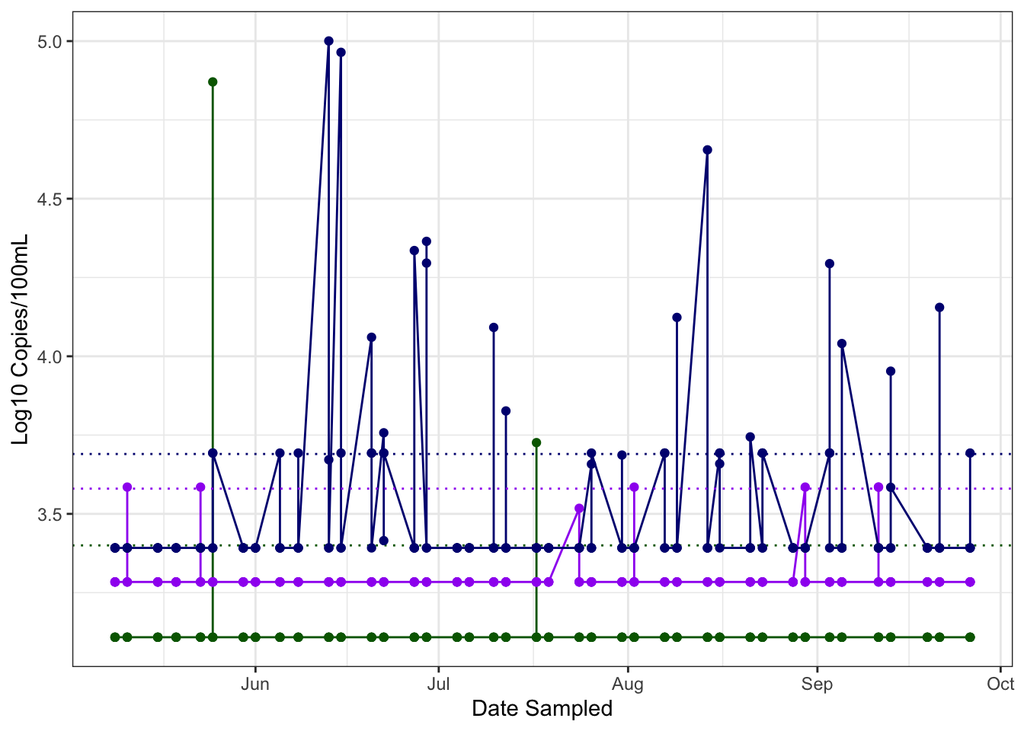

```r
Inverness_Bird_Arco <- clean_water_quality_data %>%
  filter(Pond == "Inverness") %>%
  ggplot() +
  geom_line(mapping = aes(x = Date_Sampled, y = CG01), color = "dark green") +
  geom_line(mapping = aes(x = Date_Sampled, y = LeeSg), color = "purple") +
  geom_line(mapping = aes(x = Date_Sampled, y = A_butzleri_HSP60), color = "navy") +
  geom_hline(yintercept = 3.4, colour = "dark green", linetype = "dotted") +
  geom_hline(yintercept = 3.58, colour = "purple", linetype = "dotted") +
  geom_hline(yintercept = 3.69, colour = "navy", linetype = "dotted") +
  geom_point(mapping = aes(x = Date_Sampled, y = A_butzleri_HSP60), color = "navy") +
  geom_point(mapping = aes(x = Date_Sampled, y = CG01), color = "dark green") +
  geom_point(mapping = aes(x = Date_Sampled, y = LeeSg), color = "purple") +
  labs (x = "Date Sampled", y = "Log10 Copies/100mL") +
  theme_bw()
Inverness_Bird_Arco
```

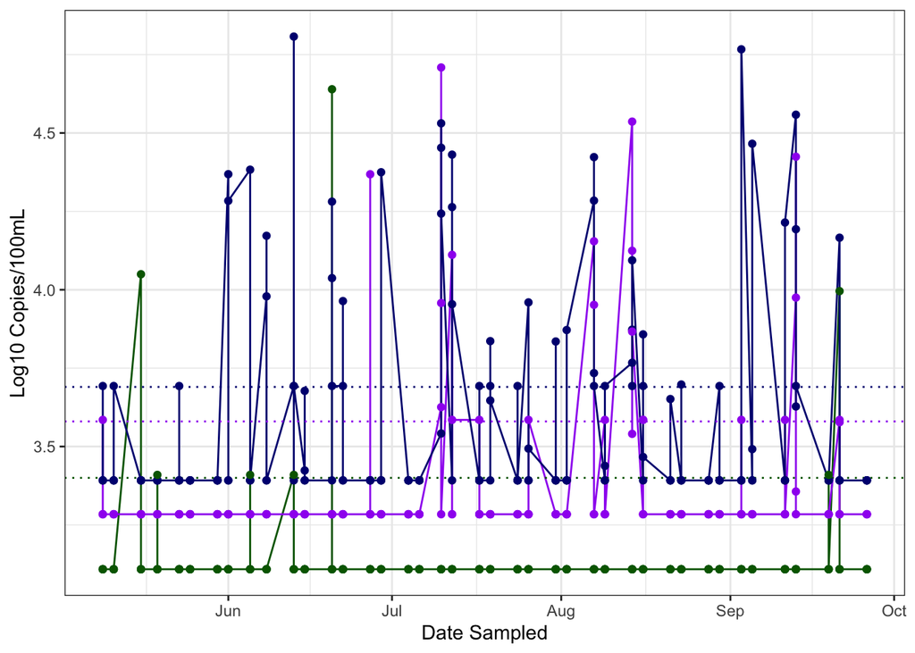

```r
ggsave(filename = "../../results/Inverness_Bird_Arco.png",plot = Inverness_Bird_Arco)
McCall_Bird_Arco <- clean_water_quality_data %>%
  filter(Pond == "McCall_Lake") %>%
  ggplot() +
  geom_line(mapping = aes(x = Date_Sampled, y = CG01), color = "dark green") +
  geom_line(mapping = aes(x = Date_Sampled, y = LeeSg), color = "purple") +
  geom_line(mapping = aes(x = Date_Sampled, y = A_butzleri_HSP60), color = "navy") +
  geom_hline(yintercept = 3.4, colour = "dark green", linetype = "dotted") +
  geom_hline(yintercept = 3.58, colour = "purple", linetype = "dotted") +
  geom_hline(yintercept = 3.69, colour = "navy", linetype = "dotted") +
  geom_point(mapping = aes(x = Date_Sampled, y = A_butzleri_HSP60), color = "navy") +
  geom_point(mapping = aes(x = Date_Sampled, y = CG01), color = "dark green") +
  geom_point(mapping = aes(x = Date_Sampled, y = LeeSg), color = "purple") +
  labs (x = "Date Sampled", y = "Log10 Copies/100mL") +
  theme_bw()
McCall_Bird_Arco
```

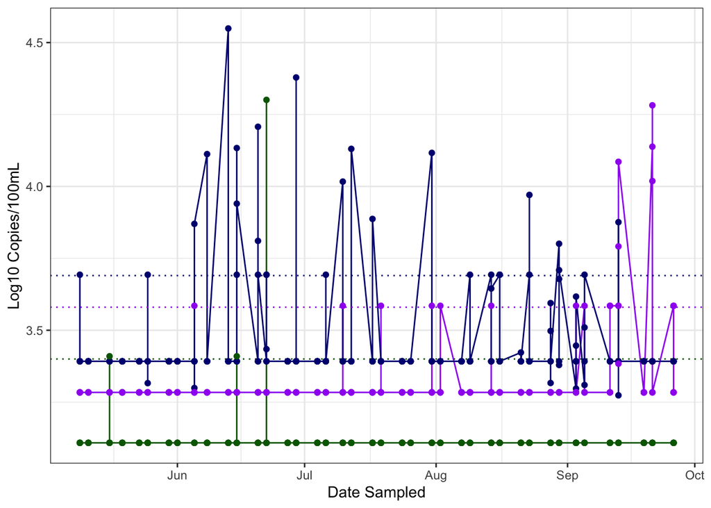

```r
ggsave(filename = "../../results/McCall_Bird_Arco.png",plot = McCall_Bird_Arco)
Country_Hills_Bird_Arco <- clean_water_quality_data %>%
  filter(Pond == "Country_Hills") %>%
  ggplot() +
  geom_line(mapping = aes(x = Date_Sampled, y = CG01), color = "dark green") +
  geom_line(mapping = aes(x = Date_Sampled, y = LeeSg), color = "purple") +
  geom_line(mapping = aes(x = Date_Sampled, y = A_butzleri_HSP60), color = "navy") +
  geom_hline(yintercept = 3.4, colour = "dark green", linetype = "dotted") +
  geom_hline(yintercept = 3.58, colour = "purple", linetype = "dotted") +
  geom_hline(yintercept = 3.69, colour = "navy", linetype = "dotted") +
  geom_point(mapping = aes(x = Date_Sampled, y = A_butzleri_HSP60), color = "navy") +
  geom_point(mapping = aes(x = Date_Sampled, y = CG01), color = "dark green") +
  geom_point(mapping = aes(x = Date_Sampled, y = LeeSg), color = "purple") +
  labs (x = "Date Sampled", y = "Log10 Copies/100mL") +
  theme_bw()
Country_Hills_Bird_Arco
```

```r
ggsave(filename = "../../results/Country_Hills_Bird_Arco.png", plot = Country_Hills_Bird_Arco)
```

*Temporal Trends One Marker Per Pond*

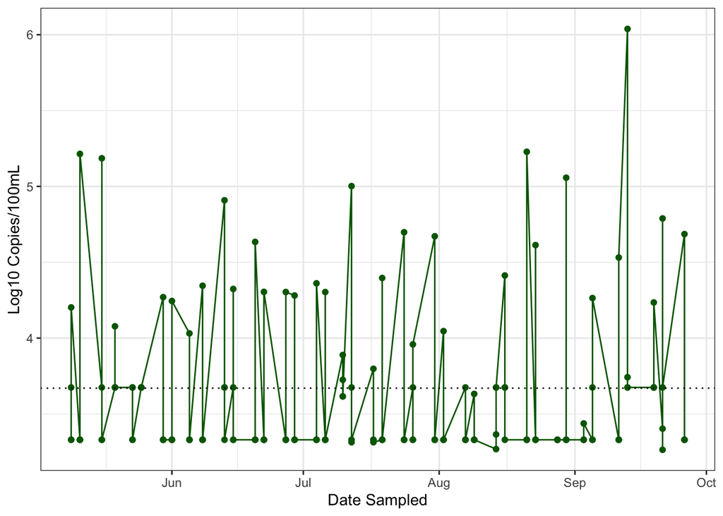

```r
McCall_HF183 <- clean_water_quality_data %>%
  filter(Pond == "McCall_Lake") %>%
  ggplot() +
  geom_line(mapping = aes(x = Date_Sampled, y = HF183), color = "dark green") +
  geom_point(mapping = aes(x = Date_Sampled, y = HF183), color = "dark green") +
  labs (x = "Date Sampled", y = "Log10 Copies/100mL") +
  geom_hline(yintercept = 3.67, colour = "black", linetype = "dotted") +
  theme_bw() +
  scale_color_discrete(name = "Legend", labels = c("HF183", "LOD95"))
McCall_HF183
```

```r
ggsave(filename = "../../results/McCall_HF183.png", plot = McCall_HF183)
```

##Exploratory Analysis - Box and Whisker Plots Boxplot of HF183 on all ponds

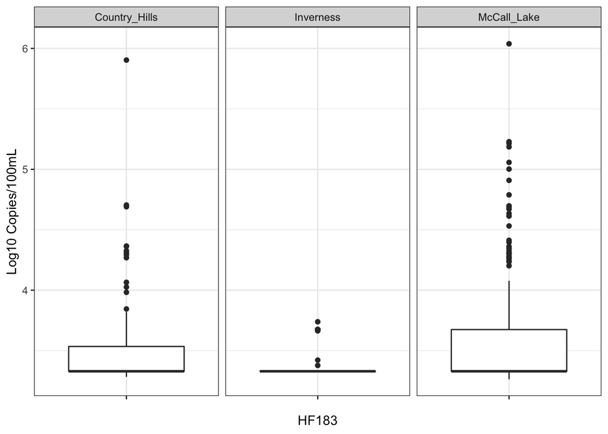

```r
All_Box_HF183 <- ggplot(data = clean_water_quality_data, aes(x = "", y = HF183)) +
  geom_boxplot() +
  facet_wrap(~ Pond) +
  theme_bw() +
  labs (x = "HF183", y = "Log10 Copies/100mL")
All_Box_HF183
```

```r
ggsave(filename = "../../results/All_Box_HF183.png", plot = All_Box_HF183)
```

Since McCall Lake has the most interesting data, lets look at the sampling sites within McCall Lake to see if one site has a higher median (is more contaminated)

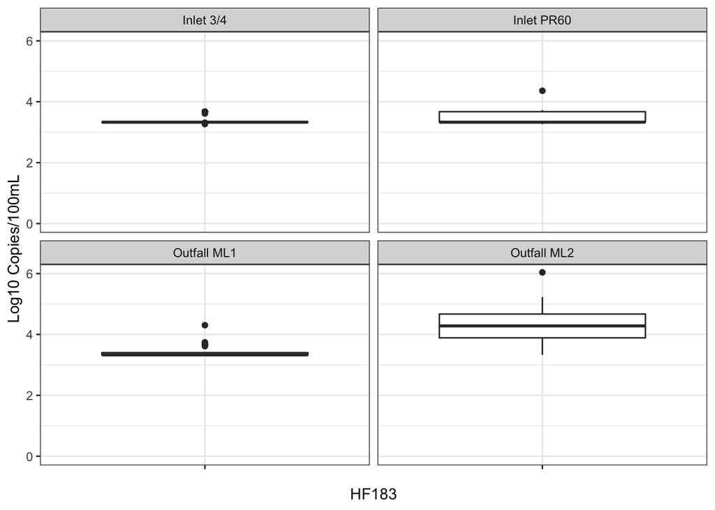

```r
McCall_bysite_box_HF183 <- clean_water_quality_data %>%
  filter(Pond == "McCall_Lake") %>%
  ggplot(aes(x = "", y = HF183)) +
  geom_boxplot() +
  coord_cartesian(ylim = c(0, 6)) +
  facet_wrap(~ Sampling_Site) +
  theme_bw() +
  labs (x = "HF183", y = "Log10 Copies/100mL")
McCall_bysite_box_HF183
```

```r
ggsave(filename = "../../results/McCall_bysite_box_HF183.png", plot = McCall_bysite_box_HF183)
```

##Explatory Analysis - Violin Plots The water quality data measured through molecular methods (i.e., Enterococcus CCE as determined by EPA Method 1611) would be best visualized using a violin plot

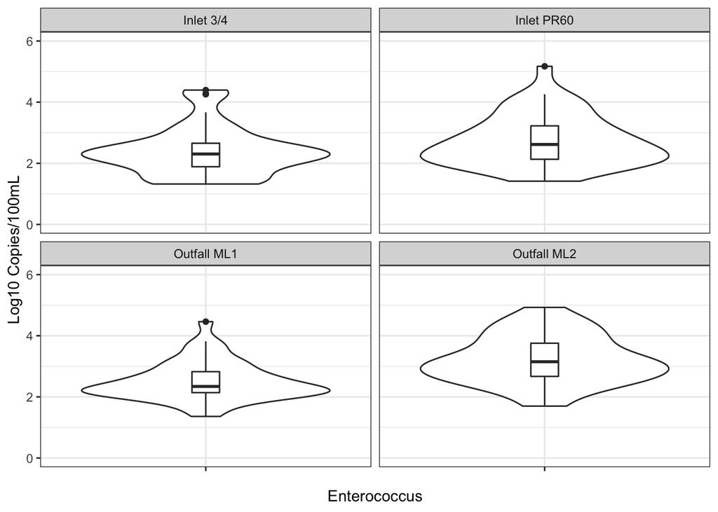

```r
McCall_Enterococcus_CCE_Violin <- clean_water_quality_data %>%
  filter(Pond == "McCall_Lake") %>%
  ggplot(aes(x = "", y = Enterococcus_CCE)) +
  geom_violin() +
  geom_boxplot(width=0.1) +
  coord_cartesian(ylim = c(0, 6)) +
  facet_wrap(~ Sampling_Site) +
  theme_bw() +
  labs (x = "Enterococcus", y = "Log10 Copies/100mL")
McCall_Enterococcus_CCE_Violin
```

```r
ggsave(filename = "../../results/McCall_Enterococcus_CCE_Violin.png", plot = McCall_Enterococcus_CCE_Violin)
```

##Exploratory Analysis - Bar Charts How many samples are positive for shigatoxin 1

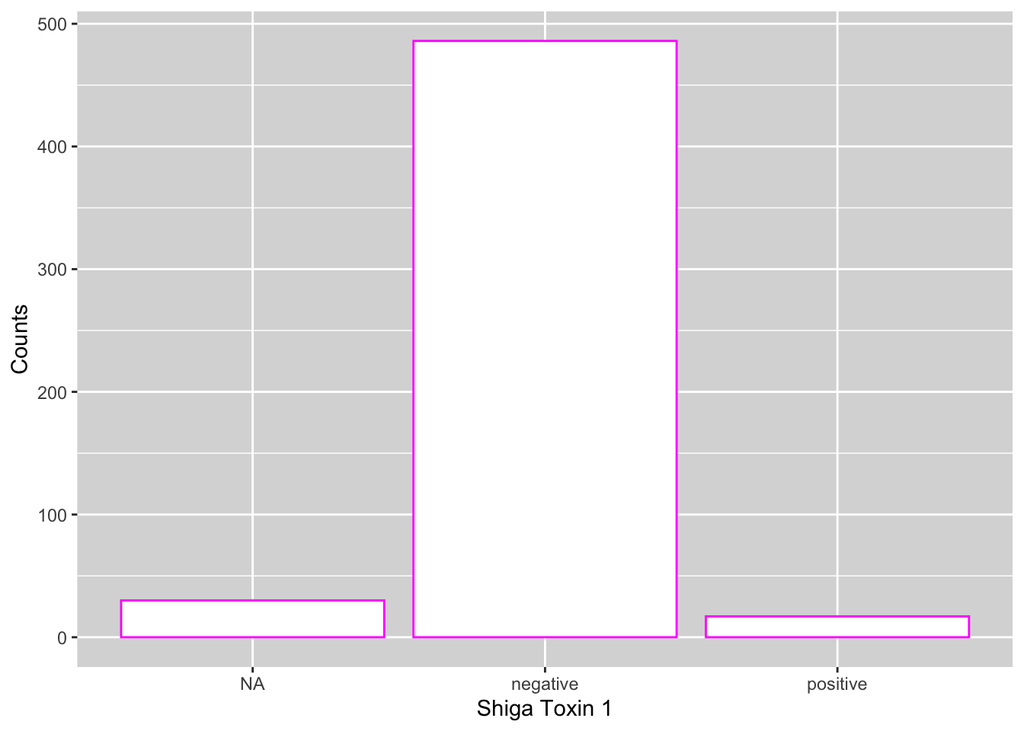

```r
Shigatoxin1_bar <- clean_water_quality_data %>%
  ggplot() +
  geom_bar(aes(x = Shigatoxin_1), stat = "count", color = "magenta", fill = "white") +
  labs(x = "Shiga Toxin 1", y = "Counts") +
  theme(panel.background = element_rect(fill = "grey85"))
Shigatoxin1_bar
```

```r
ggsave(filename = "../../results/Shigatoxin1_bar.png", plot = Shigatoxin1_bar)
```

How many samples are positive for shigatoxin 2

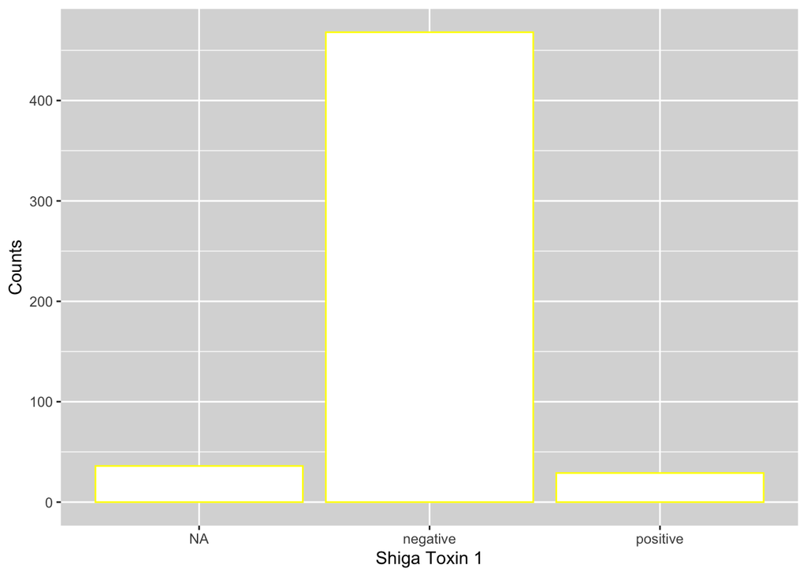

```r
Shigatoxin2_bar <- clean_water_quality_data %>%
  ggplot() +
  geom_bar(aes(x = Shigatoxin_2), stat = "count", color = "yellow", fill = "white") +
  labs(x = "Shiga Toxin 1", y = "Counts") +
  theme(panel.background = element_rect(fill = "grey85"))
Shigatoxin2_bar
```

```r
ggsave(filename = "../../results/Shigatoxin2_bar.png", plot = Shigatoxin2_bar)
```